# 📊 Analysis of a complete dataset with SBM

Fungus-tree network

Author

Sophie Donnet for the Econet group

Published

April 1, 2026

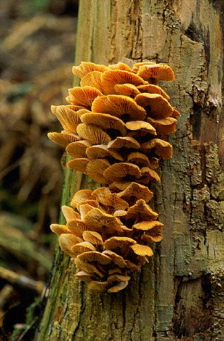

### Requirements

This tutorial follows the one on `sbm`. As before, we will need the package `sbm` package, along with some additional packages for data manipulation and visualization:

```r
library(sbm)
library(ggplot2)
library(knitr)
library(patchwork)
library(mclust)
```

## 1. An antagonistic tree/fungus interaction network

We consider the fungus-tree interaction network studied by Vacher, Piou, and Desprez-Loustau (2008), available with the package `sbm` :

This data set provides information about $154$ fungi sampled on $51$ tree species. It is a list with the following entries:

- `tree_names` : list of the tree species names
- `fungus_names`: list of the fungus species names
- `tree_tree` : weighted tree-tree interactions: number of common fungal species two tree species host.
- `fungus_tree` : binary fungus-tree interactions
- `covar_tree` : covariates associated to pairs of trees (namely genetic, taxonomic and geographic distances)

```r
data("fungusTreeNetwork")
str(fungusTreeNetwork,  max.level = 1)
```

```
#> List of 5
#>  $ tree_names  : Factor w/ 51 levels "Abies alba","Abies grandis",..: 1 2 3 14 42 4 5 6 7 8 ...
#>  $ fungus_names: Factor w/ 154 levels "Amphiporthe leiphaemia",..: 1 2 3 4 5 6 7 8 9 10 ...
#>  $ tree_tree   : num [1:51, 1:51] 0 12 9 3 2 2 0 0 2 7 ...
#>  $ fungus_tree : int [1:154, 1:51] 0 0 0 0 1 1 1 0 0 0 ...
#>  $ covar_tree  :List of 3
```

In what follows, we will first consider the simple tree-tree network in its binary and weighted versions. Then we will consider the bipartite network between trees and fungi.

# 2. Analysis of the binary 🌳–🌲 network.

## 2.1 The data

We first consider the binary network where an edge is drawn between two trees when they do share a least one common fungi:

```r
tree_tree_binary <- 1 * (fungusTreeNetwork$tree_tree != 0)
```

The function `plotMyMatrix` can be used to represent simple or bipartite SBM:

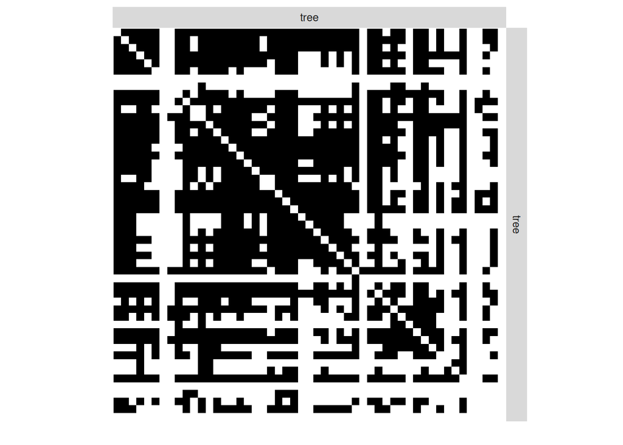

```r
plotMyMatrix(tree_tree_binary, dimLabels = list(row = 'tree', col = 'tree'))
```

## 2.2 The model

We look for some latent organization of the network by adjusting a simple SBM with the function `estimateSimpleSBM`. We assume the our matrix is the realization of the SBM model.

**Note**

The SBM model is defined as:
$$\begin{align*}
(Z_i) \text{ i.i.d.} \qquad & Z_i \sim \mathcal{M}_K(1, \pi) \\
(Y_{ij}) \text{ indep.} \mid (Z_i) \qquad & (Y_{ij} \mid Z_i=k, Z_j = \ell) \sim \mathcal{B}(\alpha_{k\ell})
\end{align*}$$

The function from `sbm` package (based on the package : `blockmodels`) infers this model with Variational EM. Note that `simpleSBM` refers to standard networks (w.r.t. bipartite).

## 2.3 Fitting the Bernoulli-SBM

We apply the VEM and ICL criterion to infer the structure of the network.

```r
mySimpleSBM <- tree_tree_binary %>%
  estimateSimpleSBM("bernoulli", directed= FALSE,
                    dimLabels ='tree',
                    estimOptions = list(verbosity = 0, plot=FALSE))
```

We can plot the ICL with respect to $K$ as follows.

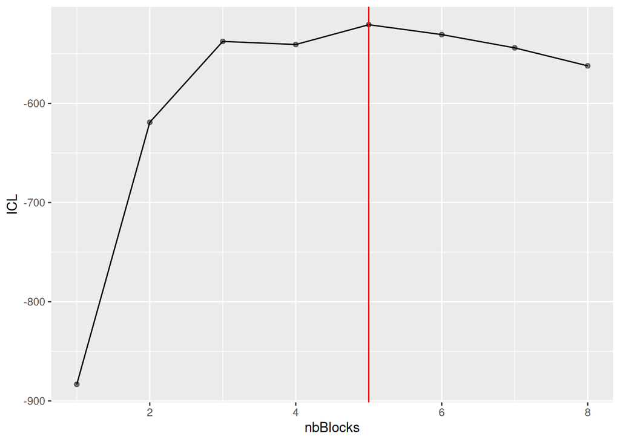

```r
mySimpleSBM$storedModels %>%
  ggplot() +
  aes(x = nbBlocks, y = ICL) + geom_line() + geom_point(alpha = 0.5) + geom_vline(xintercept = mySimpleSBM$storedModels$nbBlocks[which.max(mySimpleSBM$storedModels$ICL)],color = "red")
```

We obtain 5 blocks. We can now plot the reordered matrix.

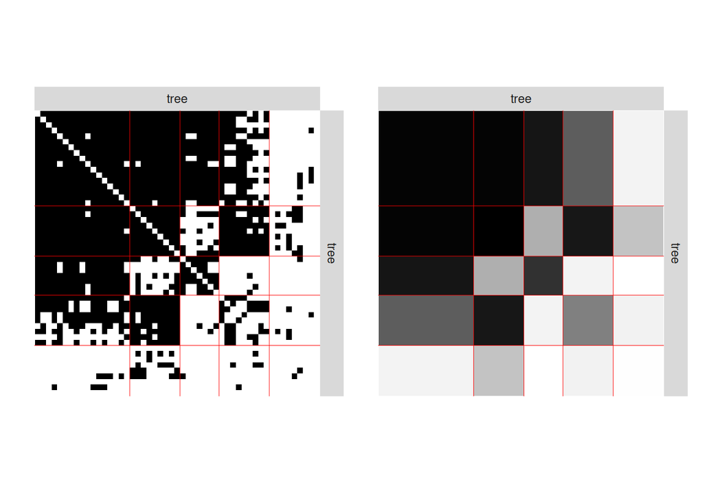

```r
p1 <- plot(mySimpleSBM, type = "data", dimLabels = list(row = 'tree', col = 'tree'))
p2 <- plot(mySimpleSBM, type = "expected", dimLabels = list(row = 'tree', col = 'tree'))
p1 | p2
```

# 3. Analysis of the weighted 🌳–🌲 network

Instead of considering the binary network tree-tree we may consider the weighted network where the link between two trees is the number of fungi they share.

We plot the matrix with function `plotMyMatrix`:

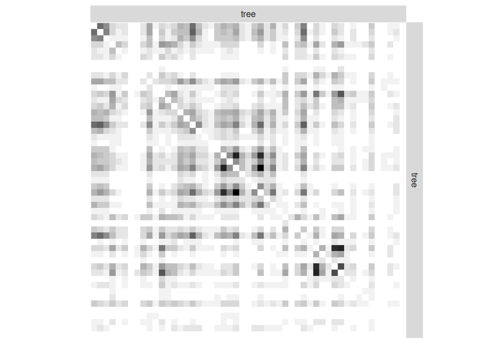

```r
tree_tree <- fungusTreeNetwork$tree_tree
plotMyMatrix(tree_tree, dimLabels = list(row = 'tree', col = 'tree'))
```

Here again, we look for some latent structure of the network by adjusting a simple SBM with the function `estimateSimpleSBM`, considering a Poisson distribution on the edges.

**Note**

The Poisson-SBM model is:
$$\begin{align*}
(Z_i) \text{ i.i.d.} \qquad & Z_i \sim \mathcal{M}_K(1, \pi) \\
(Y_{ij}) \text{ indep.} \mid (Z_i) \qquad & (Y_{ij} \mid Z_i=k, Z_j = \ell) \sim \mathcal{P}(\exp(\alpha_{kl})) = \mathcal{P}(\lambda_{kl})
\end{align*}$$

```r
mySimpleSBMPoisson <- tree_tree %>%
  estimateSimpleSBM("poisson",
                    directed = FALSE,
                    estimOptions = list(verbosity = 2 , plot = TRUE),
                    dimLabels = c('tree'))
```

We now plot the matrix reordered according to the memberships estimated in the SBM. Once again, one can also plot the expected network which, in case of the Poisson model, corresponds to the expected weight of connections between any pair of nodes in the network.

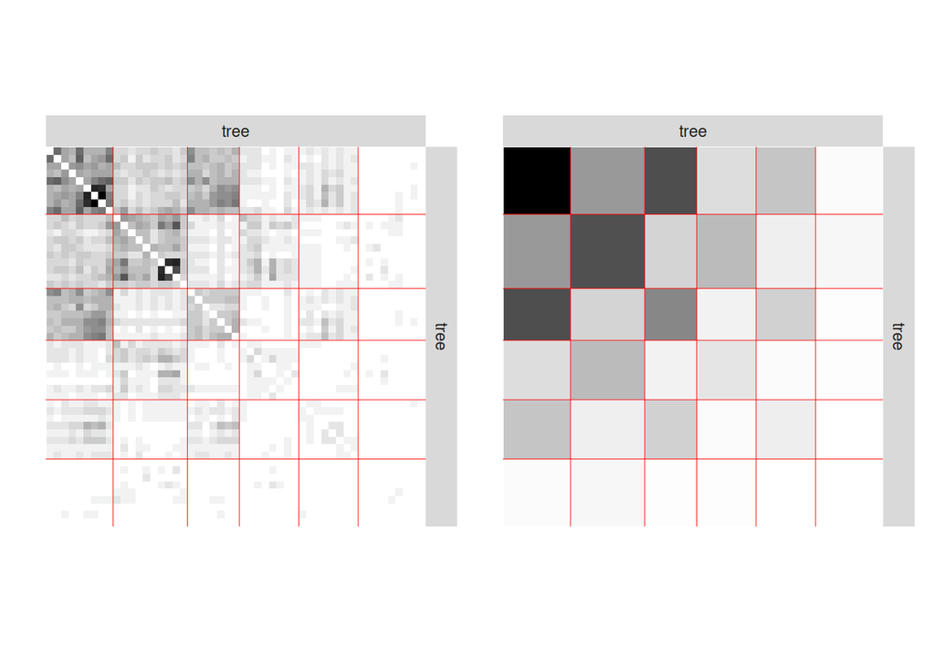

```r
plot(mySimpleSBMPoisson, type = "data") | plot(mySimpleSBMPoisson, type = "expected")
```

The composition of the clusters/blocks can be displayed by now be scrutined.

**Cluster composition**

```r
#-------------------------------------------
print_cluster = function(Z,names_Z){
  names(Z) = sub("\\(.*", "", names_Z) # short tree species names
  Z <- sort(Z)
  K <- max(Z)
  clusters <- lapply(1:K,function(k){names(Z)[Z==k]})
  max_len <- max(sapply(clusters, length))
  df <- sapply(clusters, function(x) c(x, rep('', max_len - length(x)))) %>% as.data.frame()
  names(df) <- paste('Cluster',1:K)
  return(df)
}
df <- print_cluster(mySimpleSBMPoisson$memberships, fungusTreeNetwork$tree_names)
knitr::kable(df, caption = "Tree Clusters")
```

Tree Clusters

| Cluster 1 | Cluster 2 | Cluster 3 | Cluster 4 | Cluster 5 | Cluster 6 |
| --- | --- | --- | --- | --- | --- |
| Abies alba | Large Maples | Abies nordmanniana | Small Maples | Cupressus sempervirens | Betulus spp |
| Abies grandis | Fagus silvatica | Larix kaempferi | Alnus glutinosa | Pinus brutia | Carpinus betulus |
| Cedrus spp | Fraxinus spp | Picea sitchensis | Castanea sativa | Pinus cembra | Populus tremula |
| Larix decidua | Juglans spp | Pinus halepensis | Quercus ilex | Pinus pinea | Quercus pyrenaica |
| Picea excelsa | Cultivated Poplars | Pinus nigra nigra | Quercus pubescens | Pinus radiata | Sorbus aucuparia |
| Pinus nigra laricio | Prunus avium | Pinus strobus | Quercus suber | Pinus taeda | Sorbus domestica |
| Pinus pinaster | Quercus petraea | Pinus uncinata | Sorbus aria | Platanus hybrida | Taxus baccata |
| Pinus sylvestris | Quercus robur |  | Tilia spp | Tsuga heterophylla | Thuja plicata |
| Pseudotsuga menziesii | Quercus rubra |  |  |  | Ulmus spp |
|  | Sorbus torminalis |  |  |  |  |

We are interested in comparing the two clusterings. To do so we use the alluvial flow plots and compute the ARI .

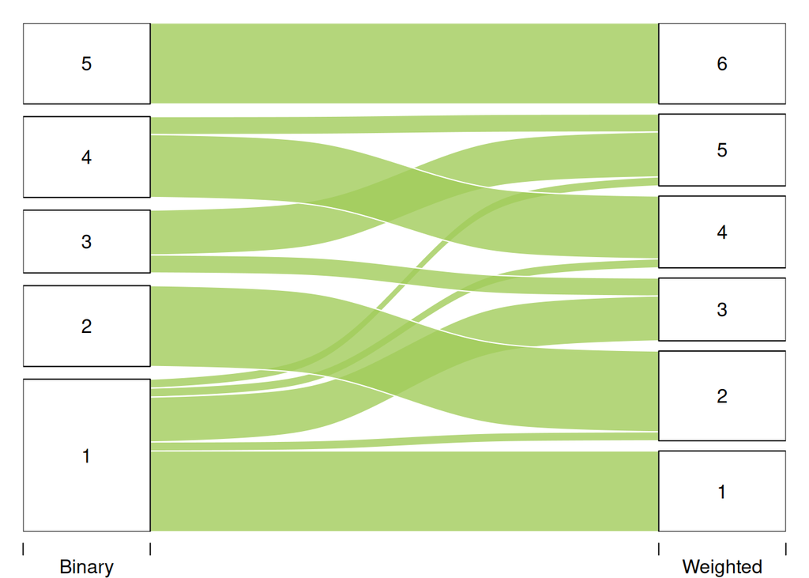

```r
listMemberships <- list(Binary = mySimpleSBM$memberships)
listMemberships$Weighted <- mySimpleSBMPoisson$memberships
ARI <- adjustedRandIndex(mySimpleSBM$memberships, mySimpleSBMPoisson$memberships)
P <- plotAlluvial(listMemberships)
```

# 4. Poisson SBM with covariates

We have on each pair of trees 3 covariates, namely the genetic distance, the taxonomic distance and the geographic distance. Each covariate has to be introduced as a matrix: $X^k_{ij}$ corresponds to the value of the $k$-th covariate describing the couple $(i,j)$.

We can also use the `sbm` package to estimate the parameters of the SBM with covariates.

**Note**

THE SBM with covariates is:
$$\begin{align*}
(Z_i) \text{ i.i.d.} \qquad & Z_i \sim \mathcal{M}(1, \pi) \\
(Y_{ij}) \text{ indep.} \mid (Z_i) \qquad & (Y_{ij} \mid Z_i=k, Z_j = \ell) \sim \mathcal{P}(\exp(\alpha_{kl} + x_{ij}^\intercal \theta)) = \mathcal{P}(\lambda_{kl}\exp(x_{ij}^\intercal \theta))
\end{align*}$$

```r
mySimpleSBMCov<- estimateSimpleSBM(
  netMat = as.matrix(tree_tree),
  model = 'poisson',
  directed =FALSE,
  dimLabels =c('tree'),
  covariates  = fungusTreeNetwork$covar_tree,
  estimOptions = list(verbosity = 2,plot=TRUE))
```

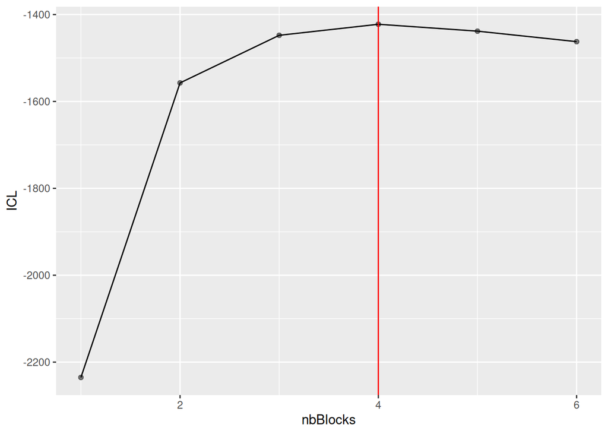

```r
mySimpleSBMCov$storedModels %>%
  ggplot() +
  aes(x = nbBlocks, y = ICL) + geom_line() + geom_point(alpha = 0.5) + geom_vline(xintercept = mySimpleSBMCov$storedModels$nbBlocks[which.max(mySimpleSBMCov$storedModels$ICL)],color = "red")
```

We now obtain 4 blocks, which is less than before. As a consequence, the covariates do explain a part of the structure. They do not explain all the structure because $K$ is still greater tant $1$.

We can now extract the parameters of interest, namely the block proportions and the effect of the covariates.

```r
mySimpleSBMCov$blockProp
```

```
#> [1] 0.3715916 0.2159544 0.2354116 0.1770425
```

```r
mySimpleSBMCov$covarParam
```

```
#>            [,1]
#> [1,]  0.1975175
#> [2,] -2.0552576
#> [3,] -0.3586006
```

We could perform a selection of the covariates by estimating the model with a subset of the complete covariate set.

```r
mySimpleSBMCov2<- estimateSimpleSBM(
  netMat = as.matrix(tree_tree),
  model = 'poisson',
  directed =FALSE,
  dimLabels =c('tree'),
  covariates  = fungusTreeNetwork$covar_tree[-1],
  estimOptions = list(verbosity = 0,plot=FALSE))
mySimpleSBMCov2$ICL - mySimpleSBMCov$ICL
```

[output not shown]

In this case, `mySimpleSBMCov2$ICL - mySimpleSBMCov$ICL >0` so the model without the genetic distance is prefered.

**Tip**

Note that the clusters do not play the same role anymore. They do not encode the structure of the network by only the residual structure after the covariates have been taking into account. As a consequence, they are difficult to interpret. Reordering the matrix with respect to this clustering may not highlight structures as clear as before.

```r
plot(mySimpleSBMCov)
```

[output not shown]

# 5. Analysis of the 🌳-🍄 network

Finally, we go back to the original data and analyze the bipartite tree/fungi interactions. The incidence matrix can be plotted with the function

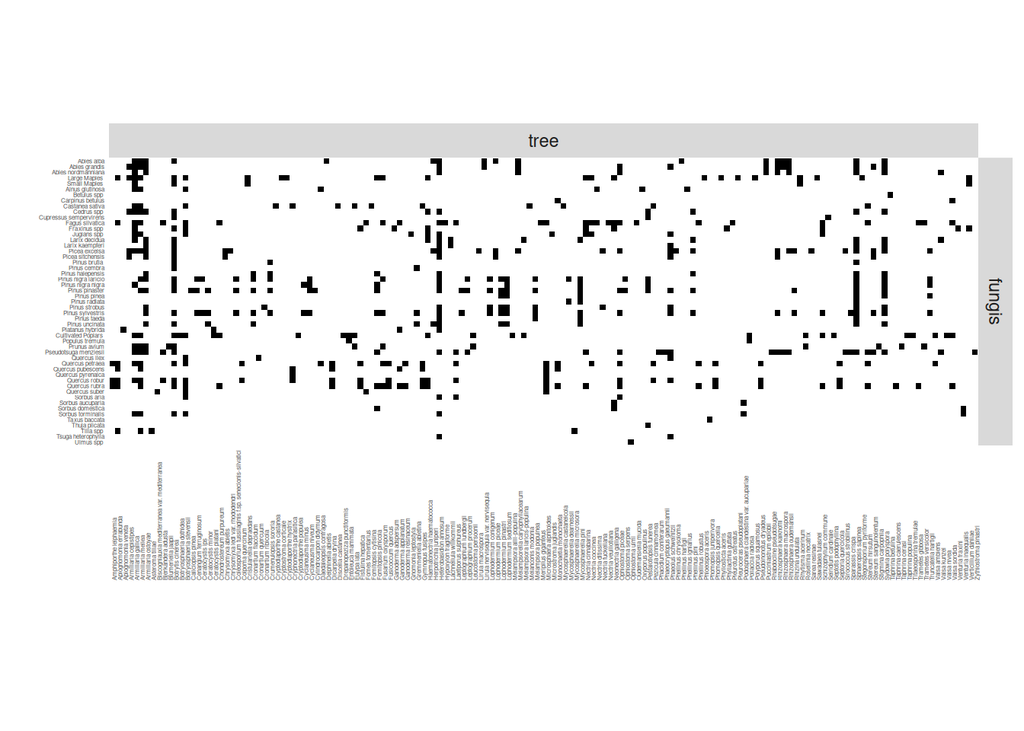

```r
biAdj <-  fungusTreeNetwork$fungus_tree
colnames(biAdj) <- sub("\\(.*", "",fungusTreeNetwork$tree_names)
row.names(biAdj) <- sub("\\(.*", "",fungusTreeNetwork$fungus_names)
plotMyMatrix(t(biAdj), dimLabels=list(col = 'fungis',row = 'tree'),plotOptions = list(colNames=TRUE, rowNames=TRUE))+ theme(
    axis.text = element_text(size = 3)
  )
```

**Note**

THE SBM adapted to bipartite network is:
$$\begin{align*}
(Z_i) \text{ i.i.d.} \qquad & Z_i \sim \mathcal{M}_K(1, \pi) \\
(W_j) \text{ i.i.d.} \qquad & W_j \sim \mathcal{M}_L(1, \rho) \\
(Y_{ij}) \text{ indep.} \mid (Z_i, W_j) \qquad & (Y_{ij} \mid Z_i=k, W_j = \ell) \sim \mathcal{B}(\alpha_{k\ell})
\end{align*}$$

```r
myBipartiteSBM <- estimateBipartiteSBM(
  netMat = as.matrix(fungusTreeNetwork$fungus_tree),
  model = 'bernoulli',
  dimLabels=c(row = 'fungis',col = 'tree'),
  estimOptions = list(verbosity = 1,plot = TRUE))
```

We can now plot the reorganized matrix.

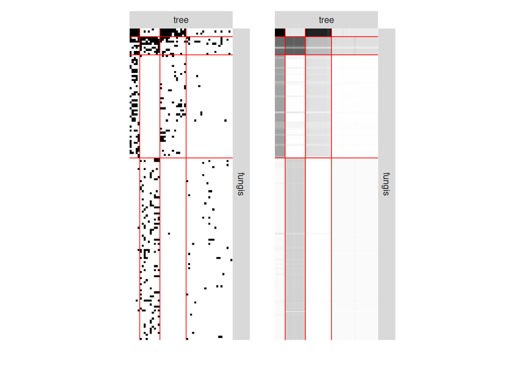

```r
plot(myBipartiteSBM, type = "data") | plot(myBipartiteSBM, type = "expected")
```

**Note**

The clusters of the trees are now:

Tree Clusters

| Cluster 1 | Cluster 2 | Cluster 3 | Cluster 4 |
| --- | --- | --- | --- |
| Picea excelsa | Large Maples | Abies alba | Small Maples |
| Pinus nigra laricio | Castanea sativa | Abies grandis | Alnus glutinosa |
| Pinus pinaster | Fagus silvatica | Abies nordmanniana | Betulus spp |
| Pinus sylvestris | Fraxinus spp | Cedrus spp | Carpinus betulus |
| Pseudotsuga menziesii | Juglans spp | Larix decidua | Cupressus sempervirens |
|  | Cultivated Poplars | Larix kaempferi | Pinus brutia |
|  | Prunus avium | Picea sitchensis | Pinus cembra |
|  | Quercus petraea | Pinus halepensis | Pinus radiata |
|  | Quercus robur | Pinus nigra nigra | Platanus hybrida |
|  | Quercus rubra | Pinus pinea | Populus tremula |
|  |  | Pinus strobus | Quercus ilex |
|  |  | Pinus taeda | Quercus pubescens |
|  |  | Pinus uncinata | Quercus pyrenaica |
|  |  |  | Quercus suber |
|  |  |  | Sorbus aria |
|  |  |  | Sorbus aucuparia |
|  |  |  | Sorbus domestica |
|  |  |  | Sorbus torminalis |
|  |  |  | Taxus baccata |
|  |  |  | Thuja plicata |
|  |  |  | Tilia spp |
|  |  |  | Tsuga heterophylla |
|  |  |  | Ulmus spp |

The clusters of the fungi are now:

Fungi clusters

| Cluster 1 | Cluster 2 | Cluster 3 | Cluster 4 |
| --- | --- | --- | --- |
| Armillaria ostoyae | Armillaria gallica | Armillaria cepistipes | Amphiporthe leiphaemia |
| Heterobasidion annosum | Armillaria mellea | Caliciopsis pinea | Apiognomonia errabunda |
| Sphaeropsis sapinea | Botrytis cinerea | Cenangium ferruginosum | Apiognomonia veneta |
| Sydowia polyspora | Botryosphaeria stevensii | Ceratocystis ips | Asteroma tiliae |
|  | Fomitopsis pinicola | Ceratocystis minor | Biscogniauxia mediterranea var. mediterranea |
|  | Fusarium oxysporum | Chrysomyxa abietis | Bjerkandera adusta |
|  | Haematonectria haematococca | Chrysomyxa ledi var. rhododendri | Blumeriella jaapii |
|  | Ophiostoma piceae | Coleosporium tussilaginis f.sp. senecionis-silvatici | Botryosphaeria dothidea |
|  | Phaeolus schweinitzii | Cronartium flaccidum | Ceratocystis platani |
|  |  | Cronartium ribicola | Chondrostereum purpureum |
|  |  | Crumenulopsis sororia | Colpoma quercinum |
|  |  | Cyclaneusma minus | Cristulariella depraedans |
|  |  | Cyclaneusma niveum | Cronartium quercuum |
|  |  | Cylindrocarpon didymum | Cryptodiaporthe castanea |
|  |  | Delphinella abietis | Cryptostroma corticale |
|  |  | Gremmeniella abietina | Cryptodiaporthe hystrix |
|  |  | Herpotrichia juniperi | Cryphonectria parasitica |
|  |  | Lachnellula willkommii | Cryptodiaporthe populea |
|  |  | Leptographium lundbergii | Daedaleopsis confragosa |
|  |  | Leptographium procerum | Dicarpella dryina |
|  |  | Lirula macrospora | Discella castanea |
|  |  | Lirula nervisequia var. nervisequia | Drepanopeziza punctiformis |
|  |  | Lophodermium conigenum | Entoleuca mammata |
|  |  | Lophodermium piceae | Eutypa lata |
|  |  | Lophodermium pinastri | Fistulina hepatica |
|  |  | Lophodermium seditiosum | Fomes fomentarius |
|  |  | Melampsorella caryophyllacearum | Fomitopsis cytisina |
|  |  | Melampsora populnea | Fusicoccum quercus |
|  |  | Mycosphaerella dearnessii | Ganoderma adspersum |
|  |  | Mycosphaerella pini | Ganoderma applanatum |

[output cut: 60 more lines]

# 6. To go further

Consider your preferred foodweb or plant-pollinator network (or the one from Day 2). Apply the sbm inference and compare the clusters to the ones introduced on Day 2.

## References

Vacher, Corinne, Dominique Piou, and Marie-Laure Desprez-Loustau. 2008. “Architecture of an Antagonistic Tree/Fungus Network: The Asymmetric Influence of Past Evolutionary History.” *PloS One* 3 (3): e1740.